# script

Description

Author

Valeria Rolle

Published

2024-10-02

**Tablas descriptivas**

|  | control (N=41) | intervencion (N=37) | P-value |
| --- | --- | --- | --- |
| contraccion_ant_2t |  |  |  |
| Mean (SD) | 14.8 (14.2) | 13.5 (11.2) | 0.177 |
| Median [Min, Q1, Q3, Max] | 17.4 [-43.0, 12.1, 23.8, 33.1] | 12.2 [-16.4, 7.16, 19.7, 37.1] |  |
| Missing | 0 (0%) | 1 (2.7%) |  |
| contraccion_lat_2t |  |  |  |
| Mean (SD) | 8.54 (9.48) | 4.04 (11.7) | 0.012 |
| Median [Min, Q1, Q3, Max] | 9.56 [-12.7, 3.25, 13.6, 27.5] | 3.27 [-14.2, -4.02, 10.3, 51.0] |  |
| Missing | 0 (0%) | 1 (2.7%) |  |
| contraccion_area_2t |  |  |  |
| Mean (SD) | 20.1 (16.9) | 12.5 (13.2) | 0.0202 |
| Median [Min, Q1, Q3, Max] | 23.8 [-24.8, 8.29, 32.9, 56.1] | 13.8 [-41.6, 4.95, 21.5, 32.6] |  |
| Missing | 0 (0%) | 1 (2.7%) |  |
| distension_ant_2t |  |  |  |
| Mean (SD) | 3.21 (13.5) | 8.36 (19.3) | 0.478 |
| Median [Min, Q1, Q3, Max] | 4.76 [-21.2, -6.47, 9.80, 50.6] | 4.07 [-13.9, -2.02, 10.8, 76.0] |  |
| Missing | 1 (2.4%) | 1 (2.7%) |  |
| distension_lat_2t |  |  |  |
| Mean (SD) | 4.41 (12.4) | 4.89 (14.3) | 0.955 |
| Median [Min, Q1, Q3, Max] | 4.56 [-41.0, -1.72, 11.8, 32.6] | 4.45 [-41.2, -2.33, 12.0, 42.6] |  |
| Missing | 1 (2.4%) | 1 (2.7%) |  |
| distension_area_2t |  |  |  |
| Mean (SD) | 11.5 (23.1) | 17.7 (35.6) | 0.559 |
| Median [Min, Q1, Q3, Max] | 8.46 [-23.0, -7.67, 18.9, 68.7] | 12.2 [-19.6, -2.74, 23.7, 181] |  |
| Missing | 1 (2.4%) | 1 (2.7%) |  |

|  | control (N=41) | intervencion (N=37) | P-value |
| --- | --- | --- | --- |
| contraccion_ant |  |  |  |
| Mean (SD) | 15.8 (9.96) | 14.7 (11.8) | 0.295 |
| Median [Min, Q1, Q3, Max] | 16.5 [-9.40, 11.8, 20.1, 34.2] | 11.5 [-4.73, 7.64, 21.4, 38.3] |  |
| Missing | 11 (26.8%) | 13 (35.1%) |  |
| contraccion_lat |  |  |  |
| Mean (SD) | 3.56 (13.1) | 8.47 (11.1) | 0.295 |
| Median [Min, Q1, Q3, Max] | 5.73 [-31.0, -0.593, 12.3, 29.6] | 8.15 [-6.12, 0.468, 16.3, 41.0] |  |
| Missing | 11 (26.8%) | 13 (35.1%) |  |
| contraccion_area |  |  |  |
| Mean (SD) | 16.2 (17.5) | 16.9 (15.7) | 0.623 |
| Median [Min, Q1, Q3, Max] | 20.1 [-20.5, 9.19, 27.8, 41.6] | 16.3 [-8.41, 4.38, 25.0, 60.1] |  |
| Missing | 11 (26.8%) | 13 (35.1%) |  |
| distension_ant |  |  |  |
| Mean (SD) | 12.2 (15.5) | 6.40 (13.4) | 0.215 |
| Median [Min, Q1, Q3, Max] | 12.1 [-11.9, 0.0381, 18.5, 47.3] | 5.91 [-23.7, -1.44, 13.8, 36.1] |  |
| Missing | 11 (26.8%) | 13 (35.1%) |  |
| distension_lat |  |  |  |
| Mean (SD) | 18.9 (16.9) | 7.64 (10.4) | 0.0111 |
| Median [Min, Q1, Q3, Max] | 15.1 [-5.97, 7.48, 29.8, 60.1] | 7.39 [-8.03, -0.774, 13.6, 31.8] |  |
| Missing | 11 (26.8%) | 13 (35.1%) |  |
| distension_area |  |  |  |
| Mean (SD) | 36.6 (32.4) | 18.0 (23.5) | 0.0476 |
| Median [Min, Q1, Q3, Max] | 31.4 [-5.00, 11.9, 52.6, 129] | 17.7 [-24.3, 4.28, 31.4, 76.7] |  |
| Missing | 11 (26.8%) | 13 (35.1%) |  |

|  | control (N=41) | intervencion (N=37) | P-value |
| --- | --- | --- | --- |
| edad_materna |  |  |  |
| Mean (SD) | 33.9 (4.19) | 32.6 (4.21) | 0.248 |
| Median [Min, Q1, Q3, Max] | 34.0 [26.0, 31.0, 37.0, 42.0] | 33.0 [21.0, 31.0, 36.0, 40.0] |  |
| peso_antes_embarazo |  |  |  |
| Mean (SD) | 65.5 (14.2) | 63.2 (12.1) | 0.579 |
| Median [Min, Q1, Q3, Max] | 61.5 [46.0, 56.0, 72.0, 120] | 65.0 [45.0, 52.0, 70.0, 95.0] |  |
| peso_1_consulta |  |  |  |
| Mean (SD) | 66.8 (14.3) | 64.4 (11.9) | 0.627 |
| Median [Min, Q1, Q3, Max] | 63.2 [48.9, 57.8, 73.6, 115] | 66.4 [47.0, 52.4, 70.0, 91.6] |  |
| altura |  |  |  |
| Mean (SD) | 163 (6.02) | 162 (6.12) | 0.225 |
| Median [Min, Q1, Q3, Max] | 163 [150, 160, 168, 181] | 160 [150, 158, 166, 175] |  |
| imc_antes |  |  |  |
| Mean (SD) | 24.5 (4.40) | 24.1 (4.15) | 0.837 |
| Median [Min, Q1, Q3, Max] | 23.1 [18.2, 21.3, 26.4, 40.1] | 24.0 [18.1, 21.1, 25.9, 35.3] |  |
| imc_ahora |  |  |  |
| Mean (SD) | 25.0 (4.44) | 24.6 (4.12) | 0.787 |
| Median [Min, Q1, Q3, Max] | 23.5 [17.4, 22.3, 27.0, 38.4] | 24.0 [18.6, 22.0, 26.3, 35.1] |  |
| concepcion |  |  |  |
| asisitida | 1 (2.5%) | 4 (11.1%) | 0.184 |
| espontánea | 39 (97.5%) | 32 (88.9%) |  |
| Missing | 1 (2.4%) | 1 (2.7%) |  |
| etnia |  |  |  |
| caucasica | 40 (97.6%) | 35 (94.6%) | 0.601 |
| sudamericana | 1 (2.4%) | 2 (5.4%) |  |
| af_antes |  |  |  |
| activa | 16 (41.0%) | 18 (48.6%) | 0.805 |
| muy activa | 5 (12.8%) | 4 (10.8%) |  |
| sedentaria | 12 (30.8%) | 12 (32.4%) |  |
| Totalmente inactiva | 6 (15.4%) | 3 (8.1%) |  |

[output cut: 293 more lines]

**[NUEVO] iciq_sf_1visit_total**

Ojo, hay 6 valores perdidos. En función de lo que figure en el paper quizá las tablas descriptivas no deberían incluir estas seis, porque no se pueden utilizar en los modelos.

Me decís que para ajustar hay que hacerlo por IMC, edad materna y paridad previa. Hay dos variables para IMC: IMC antes e IMC ahora, voy a utilizar IMC antes. Decidme si era la otra y lo cambio en un momento.

|  | control (N=41) | intervencion (N=37) | Overall (N=78) |
| --- | --- | --- | --- |
| icq_sf1_cat |  |  |  |
| No | 22 (56.4%) | 24 (72.7%) | 46 (63.9%) |
| Sí | 17 (43.6%) | 9 (27.3%) | 26 (36.1%) |
| Missing | 2 (4.9%) | 4 (10.8%) | 6 (7.7%) |

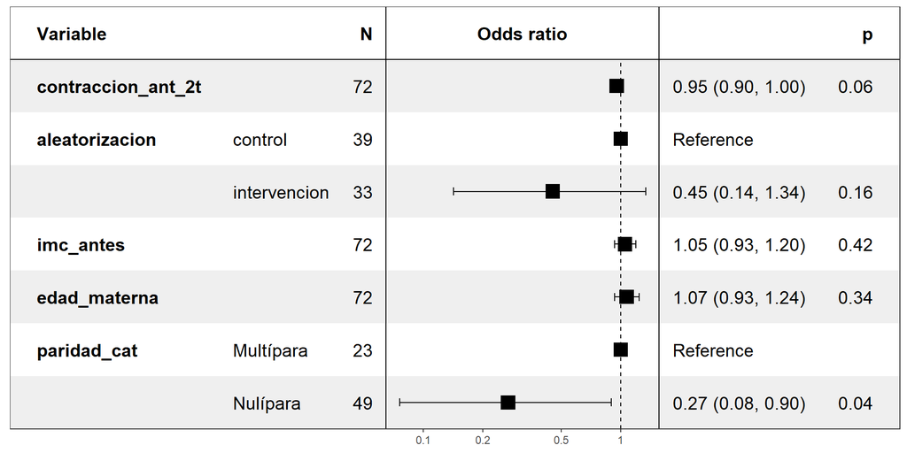

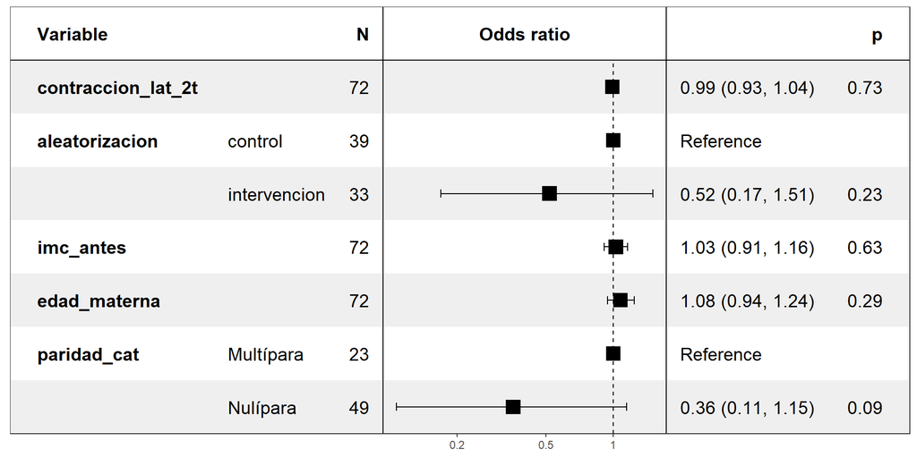

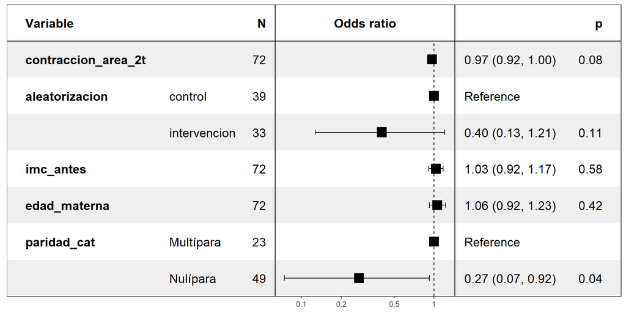

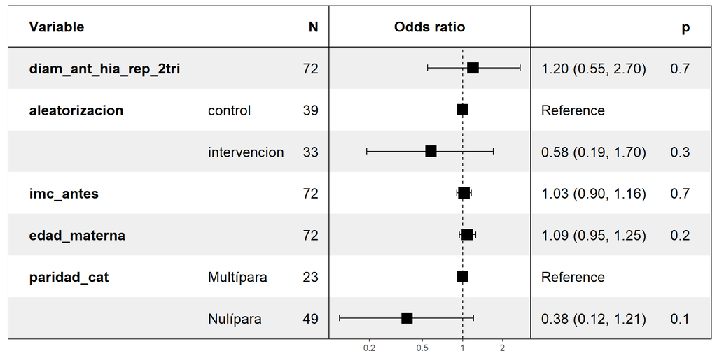

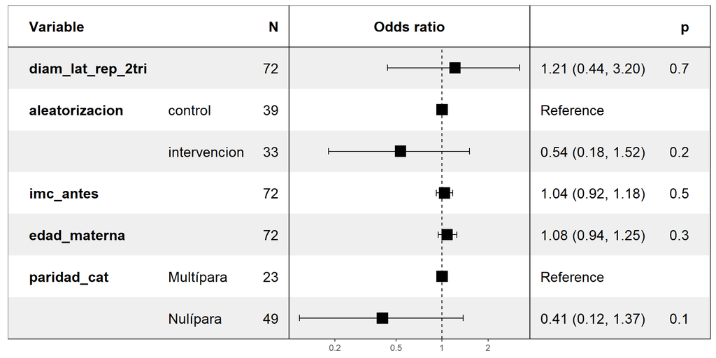

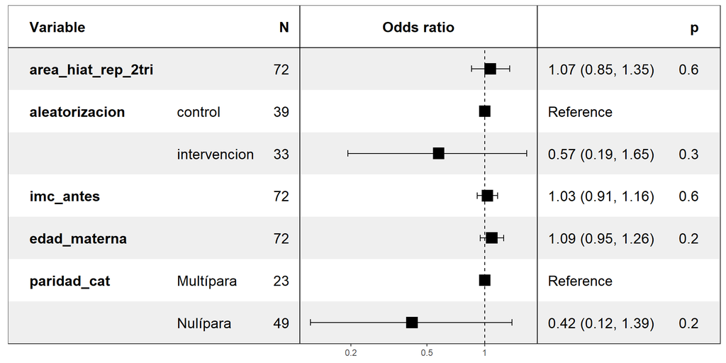

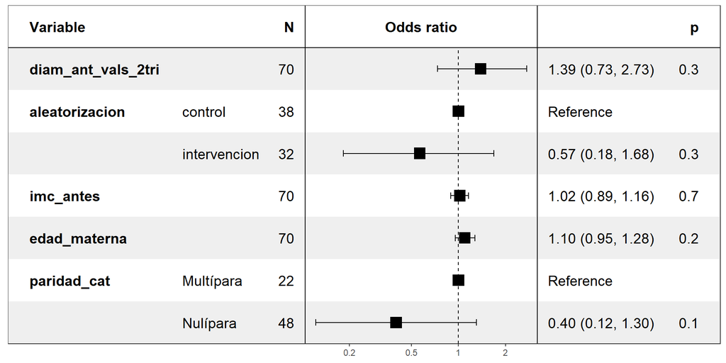

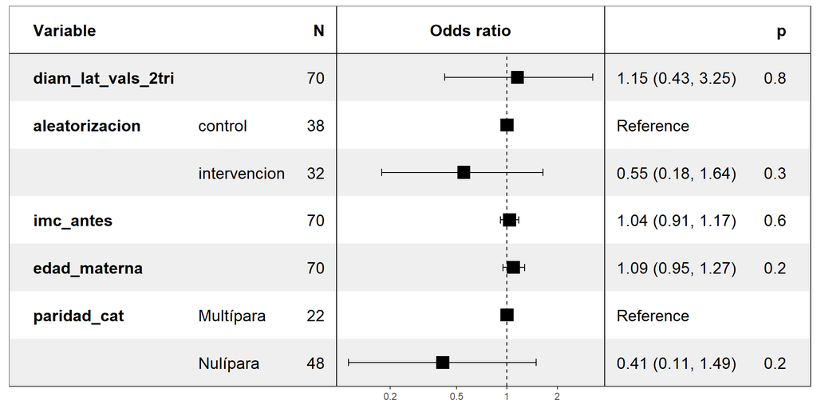

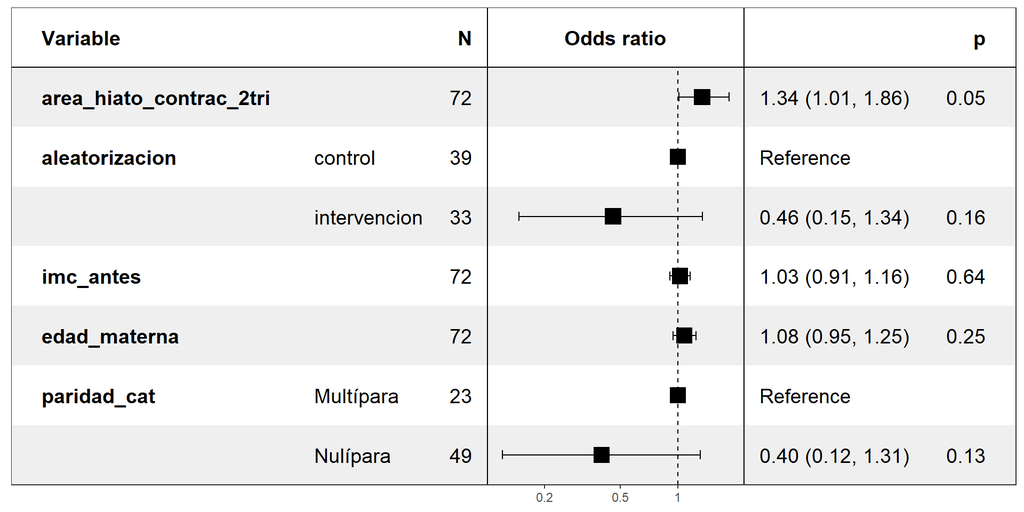

**[NUEVO] iciq_sf_1visit_total2**

Me decís que para ajustar hay que hacerlo por IMC, edad materna, paridad previa, duración del parto, tipo de parto y peso fetal. Hay dos variables para IMC: IMC antes e IMC ahora, voy a utilizar IMC antes. Decidme si era la otra y lo cambio en un momento.

Son bastantes variables para la n que tenemos (el grupo más pequeño tiene 20), deberíamos tener 2 o 3 variables de ajuste.

He quitado “tipo de parto” porque no converge, ninguna de las que tuvo cesárea tiene ≥3.

|  | control (N=41) | intervencion (N=37) | Overall (N=78) |
| --- | --- | --- | --- |
| icq_sf1_cat |  |  |  |
| <3 | 26 (72.2%) | 23 (69.7%) | 49 (71.0%) |
| ≥3 | 10 (27.8%) | 10 (30.3%) | 20 (29.0%) |
| Missing | 5 (12.2%) | 4 (10.8%) | 9 (11.5%) |

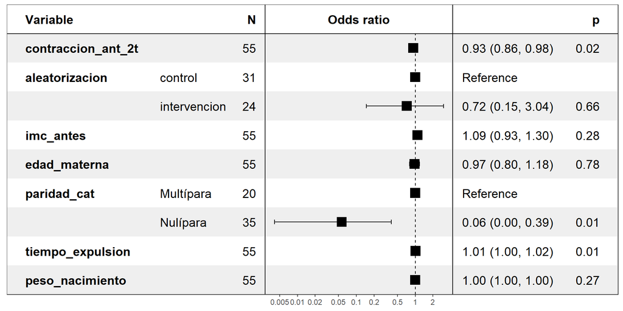

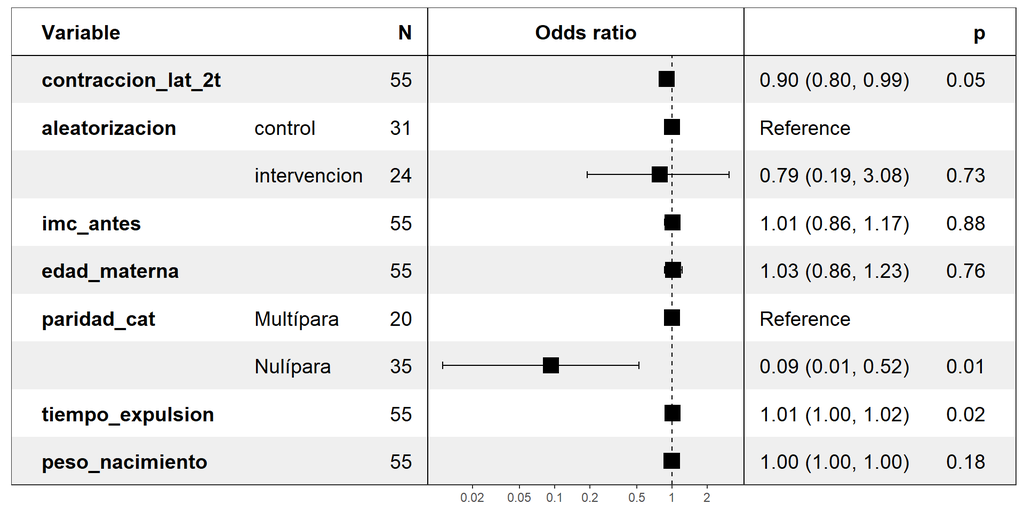

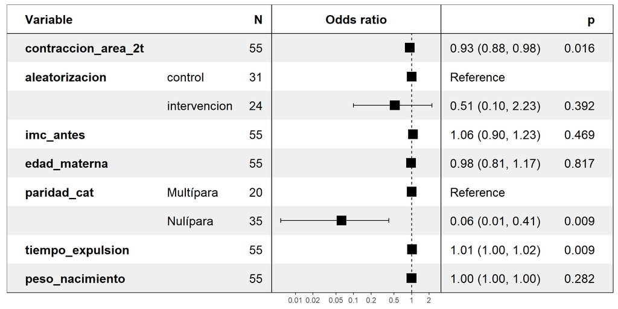

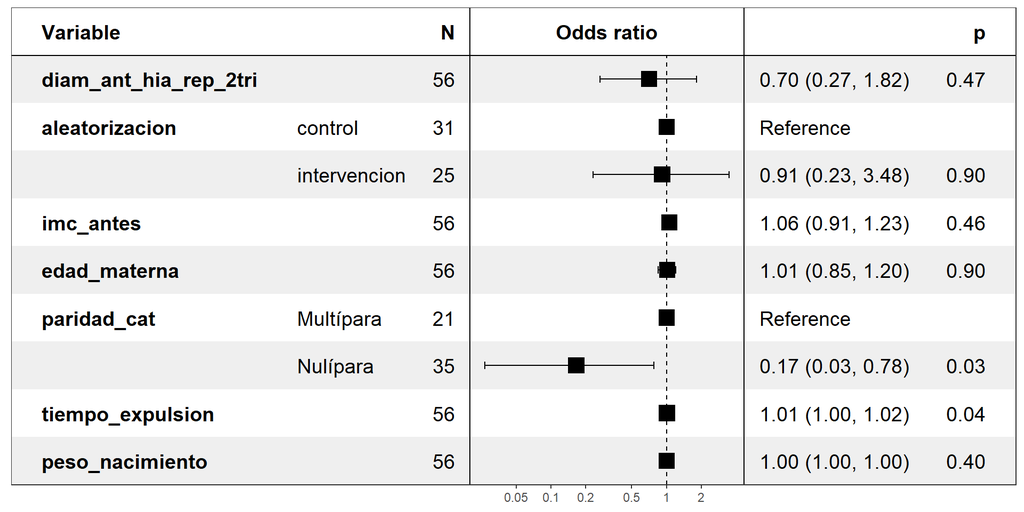

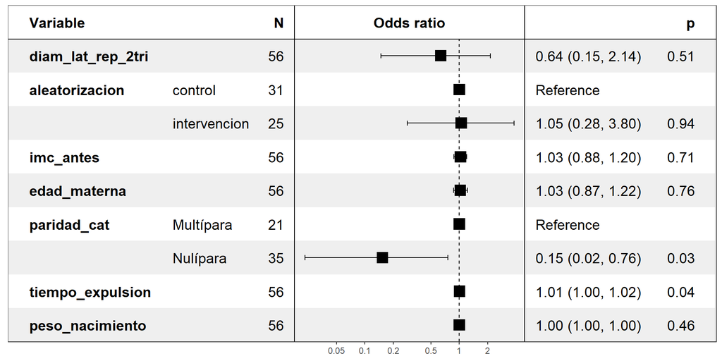

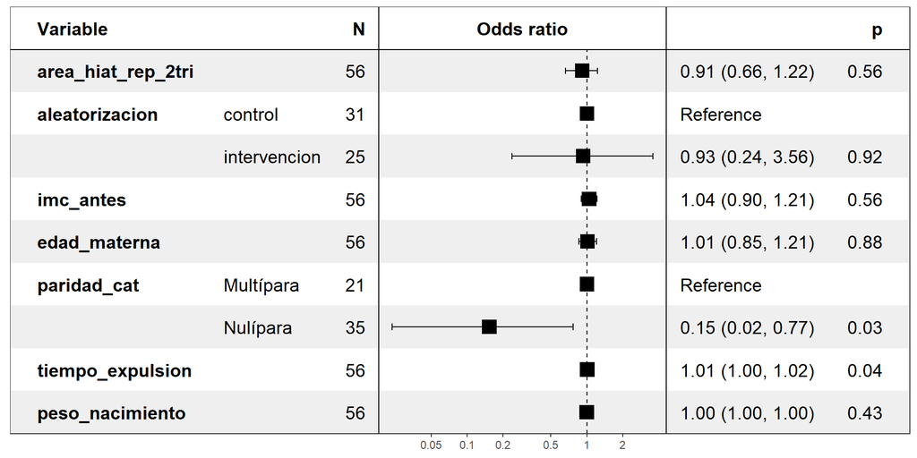

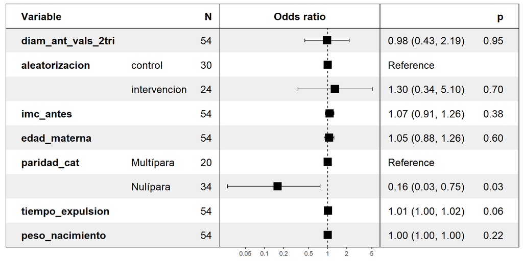

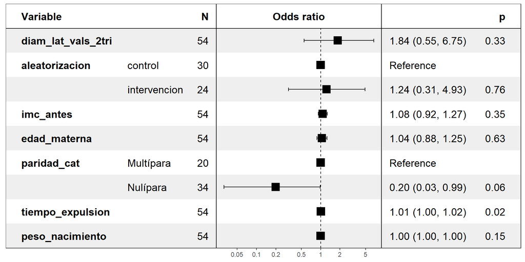

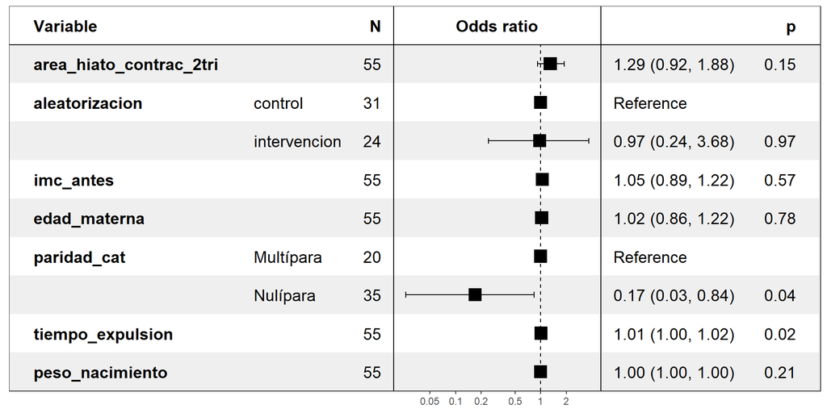

**icq_sf_1visita_final**

|  | control (N=41) | intervencion (N=37) | Overall (N=78) |
| --- | --- | --- | --- |
| icq_sf1_cat |  |  |  |
| No | 21 (53.8%) | 24 (72.7%) | 45 (62.5%) |
| Sí | 18 (46.2%) | 9 (27.3%) | 27 (37.5%) |
| Missing | 2 (4.9%) | 4 (10.8%) | 6 (7.7%) |

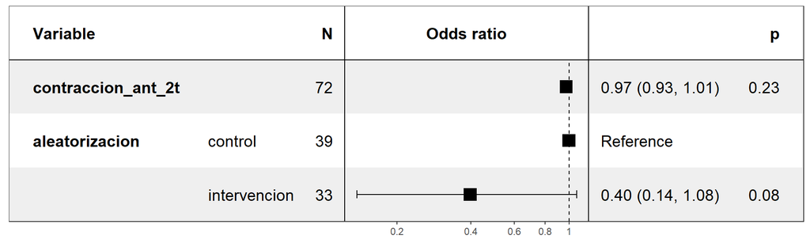

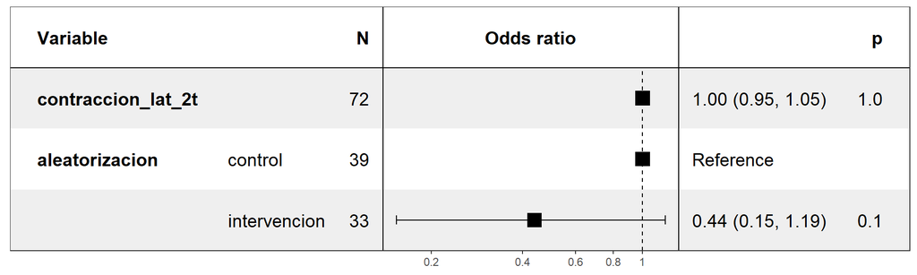

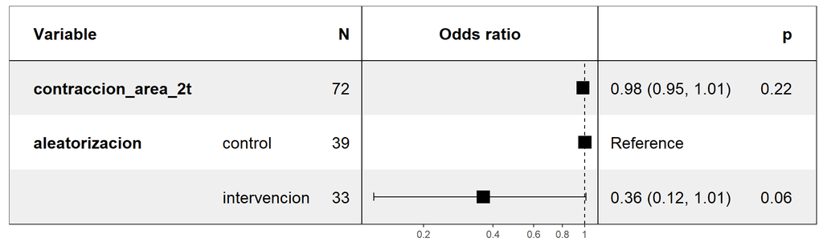

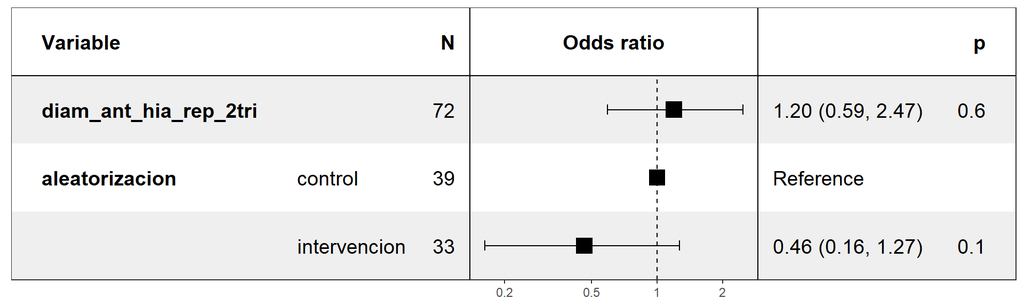

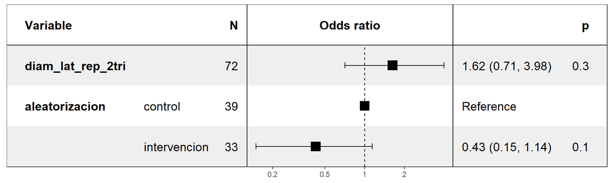

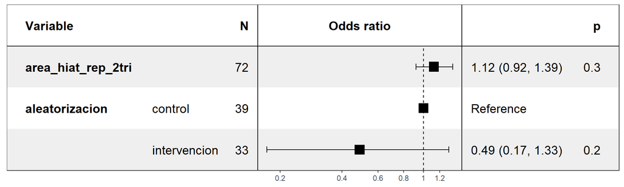

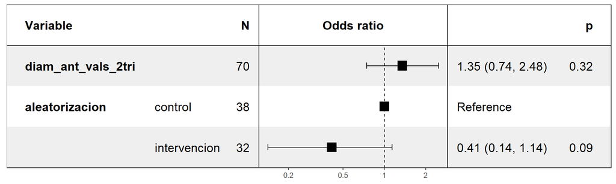

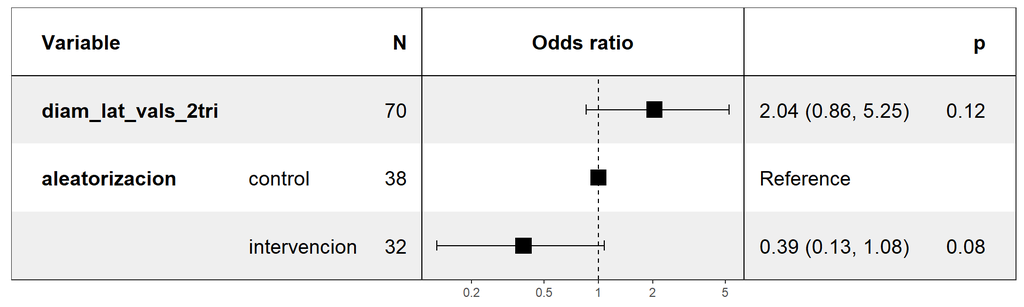

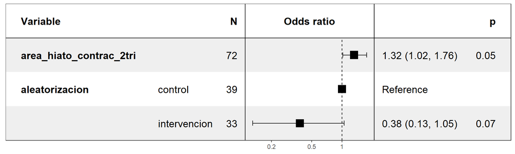